# PC2 - Adriana Sierra 20182553

## 1. Explicación de la extensión, qué hace, en qué casos sirve.

Se eligió la extensión ggsignif con el fin de agrupar en un solo gráfico todos los boxplots generados a partir en la BBDD “Matri”. Esta es útil cuando se desea resaltar las diferencias significativas entre grupos en un gráfico de barras, cajas, o cualquier otro gráfico que permita comparaciones entre grupos.

Llamamos a las librerías

```r
library(ggplot2)
library(ggsignif)
```

## 2. Ejemplo de aplicación (aplicar código)

Usaré la base de datos del Trabajo final (Matriculados en universidades a nivel nacional)

```r
library(tidyverse)
library(dplyr)
library(readxl)
library(Hmisc)
library(gtsummary)
library(tidyr)

matri<-read_xlsx("Matriculados.xlsx",skip = 2)
matri<-head(matri,-5)#eliminando ultimas filas porque son NA's
```

```r
matri<-matri |>
  select(Universidad,`Tipo de gestión`,`Grupos de programas`,Programa,`Departamento local`,`Provincia local`,`Distrito local`,`Total de estudiantes`, `Número de matriculados hombres`, `Número de matriculados mujeres`,`Número de matriculados menores de 17 años de edad`,`Número de matriculados de 18 a 24 años de edad`,`Número de matriculados de 25 a 29 años de edad`,`Número de matriculados de 30 a 35 años de edad`,`Número de matriculados mayores de 36 años de edad`,`Número de personas con discapacidad`)
```

```r
matri[,8:16]<-lapply(matri[,8:16], as.numeric)
```

```r
matri[, 8:16] <- lapply(matri[, 8:16], function(x) replace(x, is.na(x), 0))
```

```r
matri <- matri |> rename(
  Departamento = 'Departamento local',
  Provincia = 'Provincia local',
  Distrito = 'Distrito local')
```

Ahora hacemos los box plots

Primero del número total de alumnos matriculados en universidades licenciadas por Sunedu.

```
## [1] 1230230
```

```
##    Min. 1st Qu.  Median    Mean 3rd Qu.    Max.
##     1.0   148.0   289.0   461.8   534.0  6059.0
```

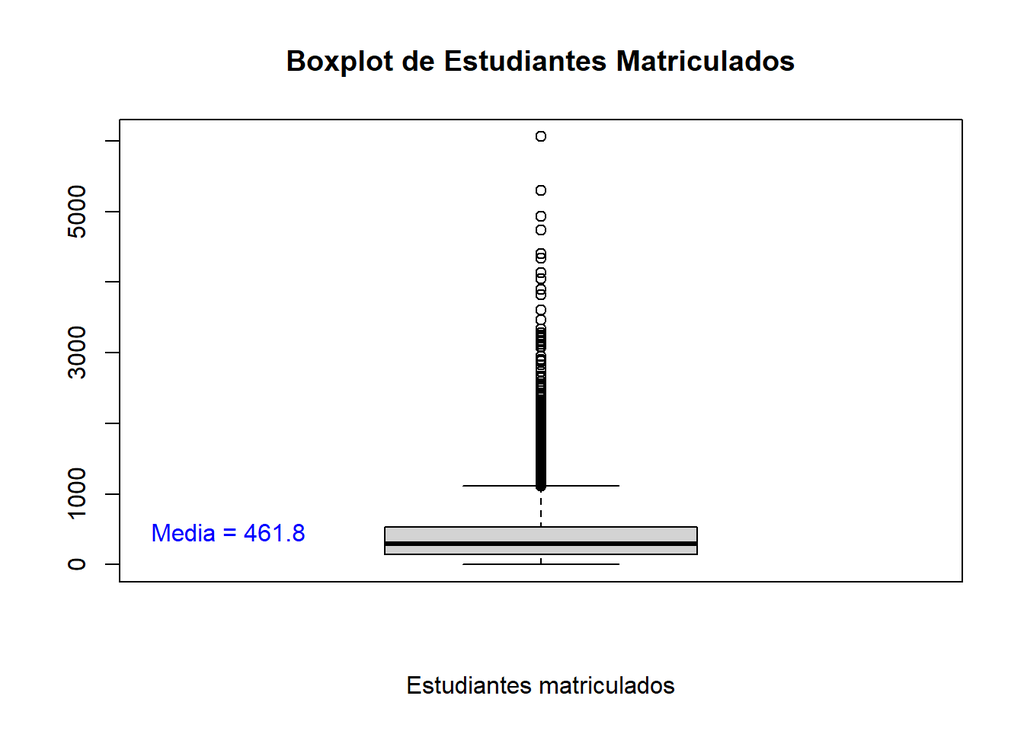

A continuación, se presentan los descriptivos del número de estudiantes matriculados hombres y su boxplot respectivo.

```
##    Min. 1st Qu.  Median    Mean 3rd Qu.    Max.
##     0.0    54.0   132.0   224.3   273.2  3109.0
```

```
## [1] 597598
```

```
## [1] 48.57612
```

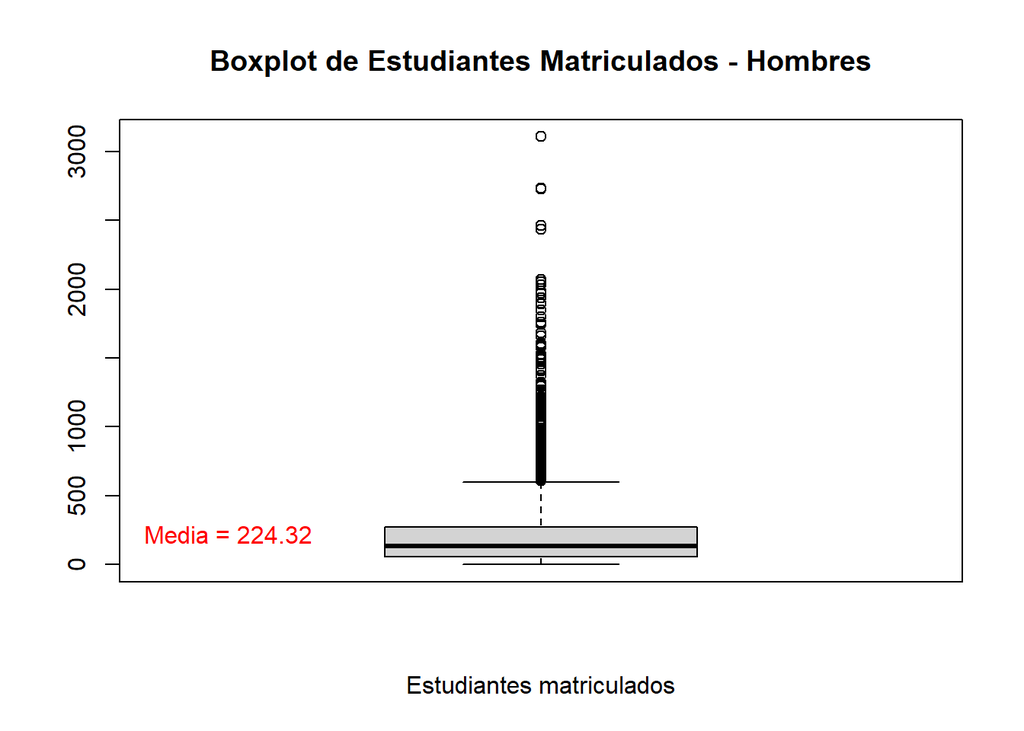

```
##    Min. 1st Qu.  Median    Mean 3rd Qu.    Max.
##     0.0    51.0   131.0   237.5   278.0  3675.0
```

```
## [1] 632632
```

```
## [1] 51.42388
```

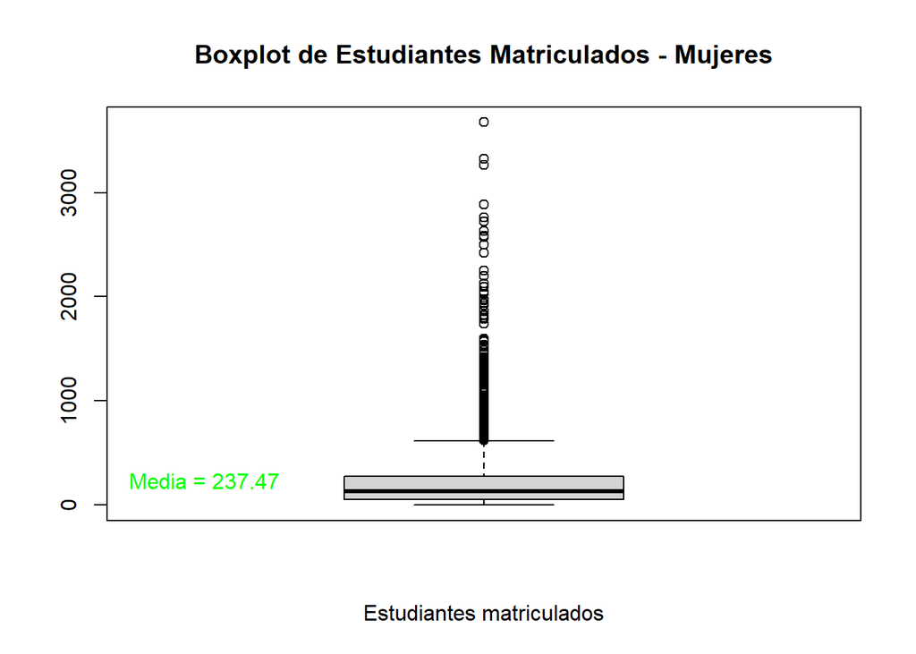

Ahora aplicaremos la extensión. Antes, creamos un dataframe con los datos del total, hombres y mujeres, ya que ggsignif necesita que los datos estén en columnas para extraerlos y hacer el boxplot final.

```r
matri_long <- data.frame(
  category = rep(c("Total", "Hombres", "Mujeres"), each = nrow(matri)),
  value = c(matri$`Total de estudiantes`, matri$`Hombres`, matri$`Mujeres`)
)
```

Ahora utilizamos ggsignif

[figure not shown]

```r
# Crear el gráfico de caja con las comparaciones deseadas
plotfinal <- ggplot(matri_long, aes(category, value)) +
  geom_boxplot() +
  geom_signif(
    comparisons = list(c("Total", "Hombres"), c("Hombres", "Mujeres")),
    map_signif_level = TRUE, textsize = 6
  ) +
  ylim(NA, max(matri_long$value, na.rm = TRUE)) +
  labs(
    title = "Comparación de boxplots",
    subtitle = "Total  vs hombres vs mujeres",
    x = "Categoría",
    y = "Conteo",
    caption = "Fuente: TUNI - SIU Sunedu") + theme_minimal()

# Mostrar el gráfico
plotfinal
```

## 3. ¿En qué otros temas se podría aplicar ggsifnif?

La extensión podría utilizarse para Comparar la media o la mediana de diferentes grupos o condiciones, comparar tendencias entre grupos en un gráfico de líneas, comparar los resultados de diferentes tratamientos en un experimento ANOVA, comparar gráficos de dispersión o correlaciones, entre otros.